# AIML_ML_Project_full_code_notebook_4

## Model Performance Improvement

## Pre-pruning :

```python
# Define the parameters of the tree to iterate over
max_depth_values = np.arange(2, 11, 2)
max_leaf_nodes_values = np.arange(10,61,10)
min_samples_split_values = np.arange(10,61,10)

# Initialize variables to store the best model and its performance
best_estimator = None
best_score_diff = float('inf')
best_test_score = 0.0

# Iterate over all combinations of the specified parameter values
for max_depth in max_depth_values:
    for max_leaf_nodes in max_leaf_nodes_values:
        for min_samples_split in min_samples_split_values:

            # Initialize the tree with the current set of parameters
            estimator = DecisionTreeClassifier(
                max_depth=max_depth,
                max_leaf_nodes=max_leaf_nodes,
                min_samples_split=min_samples_split,
                class_weight='balanced',
                random_state=42
            )

            # Fit the model to the training data
            estimator.fit(x_train, y_train)

            # Make predictions on the training and test sets
            y_train_pred = estimator.predict(x_train)
            y_test_pred = estimator.predict(x_test)

            # Calculate recall scores for training and test sets
            train_recall_score = recall_score(y_train, y_train_pred)
            test_recall_score = recall_score(y_test, y_test_pred)

            # Calculate the absolute difference between training and test recall scores
            score_diff = abs(train_recall_score - test_recall_score)

            # Update the best estimator and best score if the current one has a smaller score difference
            if (score_diff < best_score_diff) & (test_recall_score > best_test_score):
                best_score_diff = score_diff
                best_test_score = test_recall_score
                best_estimator = estimator

# Print the best parameters
print("Best parameters found:")
print(f"Max depth: {best_estimator.max_depth}")
print(f"Max leaf nodes: {best_estimator.max_leaf_nodes}")
print(f"Min samples split: {best_estimator.min_samples_split}")
print(f"Best test recall score: {best_test_score}")
```

```
Best parameters found:
Max depth: 2
Max leaf nodes: 10
Min samples split: 10
Best test recall score: 1.0
```

```python
# Let us fitting the best algorithm :
estimator = best_estimator
estimator.fit(x_train, y_train)
```

```
DecisionTreeClassifier(class_weight='balanced', max_depth=2, max_leaf_nodes=10,
                       min_samples_split=10, random_state=42)
```

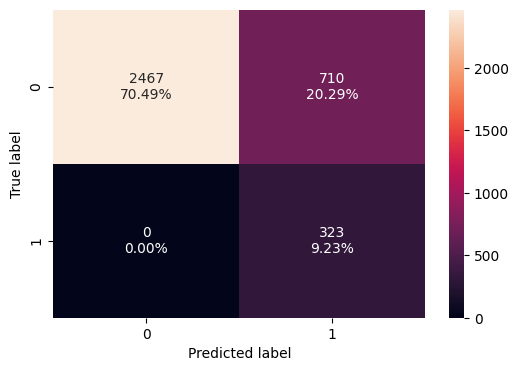

```python
# let us check the performance and confusion matrix:
confusion_matrix_sklearn(estimator, x_train, y_train)
```

- We can notice that the FN is 0 and the FP is high.

```python
# let us chrck the metris:
decision_tree_pre_prunning_perf_train = model_performance_classification_sklearn(estimator,x_train, y_train)
decision_tree_pre_prunning_perf_train
```

|  | Accuracy | Recall | Precision | F1 |
| --- | --- | --- | --- | --- |
| 0 | 0.797143 | 1.0 | 0.312682 | 0.476401 |

- we can notice that the preciousion is too low only 0.312, f1 also too low 0.476 and the accuracy is lower than what it was in default tree while the recall is perfect as 1.

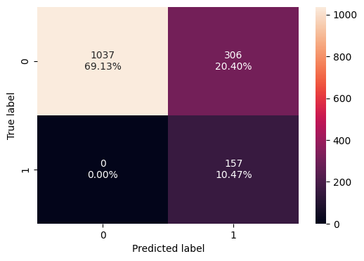

```python
# Let us check the performance for the test:
confusion_matrix_sklearn(estimator, x_test, y_test)
```

```python
# let us chrck the metris:
decision_tree_pre_prunning_perf_test = model_performance_classification_sklearn(estimator,x_test, y_test)
decision_tree_pre_prunning_perf_test
```

|  | Accuracy | Recall | Precision | F1 |
| --- | --- | --- | --- | --- |
| 0 | 0.796 | 1.0 | 0.339093 | 0.506452 |

- We can notice the same result as in training.

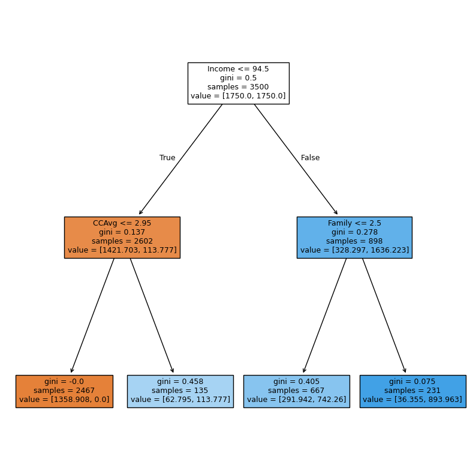

```python
# Visualizing the tree for preprunning model:
plt.figure(figsize=(10, 10))
out = tree.plot_tree(
    estimator,
    feature_names=feature_names,
    filled=True,
    fontsize=9,
    node_ids=False,
    class_names=None,
)
# below code will add arrows to the decision tree split if they are missing
for o in out:
    arrow = o.arrow_patch
    if arrow is not None:
        arrow.set_edgecolor("black")
        arrow.set_linewidth(1)
plt.show()
```

```python
# The report for the preprunning algorithm:
print(tree.export_text(estimator, feature_names=feature_names, show_weights=True))
```

```
|--- Income <= 94.50
|   |--- CCAvg <= 2.95
|   |   |--- weights: [1358.91, 0.00] class: 0
|   |--- CCAvg >  2.95
|   |   |--- weights: [62.80, 113.78] class: 1
|--- Income >  94.50
|   |--- Family <= 2.50
|   |   |--- weights: [291.94, 742.26] class: 1
|   |--- Family >  2.50
|   |   |--- weights: [36.36, 893.96] class: 1
```

```python
# importance of features :

print(
    pd.DataFrame(
        estimator.feature_importances_, columns=["Imp"], index=x_train.columns
    ).sort_values(by="Imp", ascending=False)
)
```

```
                         Imp
Income              0.840947
CCAvg               0.109958
Family              0.049095
Age                 0.000000
Experience          0.000000
Mortgage            0.000000
Securities_Account  0.000000
CD_Account          0.000000
Online              0.000000
CreditCard          0.000000
Education_2         0.000000
Education_3         0.000000
```

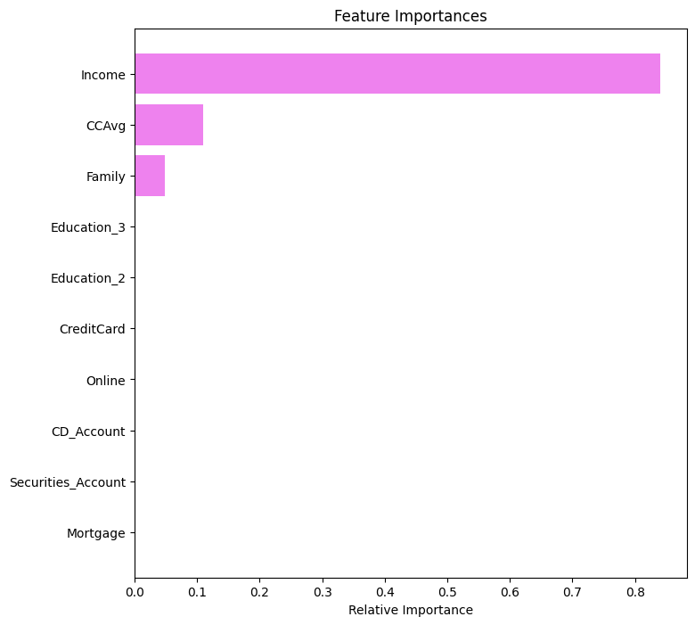

```python
importances = estimator.feature_importances_
indices = np.argsort(importances)
N=10
Top_indices = indices[-N:]
plt.figure(figsize=(8, 8))
plt.title("Feature Importances")
plt.barh(range(N), importances[Top_indices], color="violet", align="center")
plt.yticks(range(N), [feature_names[i] for i in Top_indices])
plt.xlabel("Relative Importance")
plt.show()
```

## Post-prunning:

```python
clf = DecisionTreeClassifier(random_state=1)
path = clf.cost_complexity_pruning_path(x_train, y_train)
ccp_alphas, impurities = path.ccp_alphas, path.impurities
```

```python
pd.DataFrame(path)
```

|  | ccp_alphas | impurities |
| --- | --- | --- |
| 0 | 0.000000 | 0.000000 |
| 1 | 0.000257 | 0.000514 |
| 2 | 0.000264 | 0.001569 |
| 3 | 0.000267 | 0.002103 |
| 4 | 0.000275 | 0.002652 |
| 5 | 0.000284 | 0.003220 |
| 6 | 0.000381 | 0.003600 |
| 7 | 0.000381 | 0.003981 |
| 8 | 0.000381 | 0.004743 |
| 9 | 0.000381 | 0.005124 |
| 10 | 0.000425 | 0.006400 |
| 11 | 0.000429 | 0.006829 |
| 12 | 0.000429 | 0.007686 |
| 13 | 0.000429 | 0.008115 |
| 14 | 0.000439 | 0.009869 |
| 15 | 0.000440 | 0.011188 |
| 16 | 0.000457 | 0.011645 |
| 17 | 0.000509 | 0.012154 |
| 18 | 0.000531 | 0.014276 |
| 19 | 0.000535 | 0.014811 |
| 20 | 0.000539 | 0.016429 |
| 21 | 0.000555 | 0.016984 |
| 22 | 0.000686 | 0.017669 |
| 23 | 0.000794 | 0.018464 |
| 24 | 0.000914 | 0.019378 |
| 25 | 0.000940 | 0.020317 |
| 26 | 0.000951 | 0.021269 |
| 27 | 0.000972 | 0.022240 |
| 28 | 0.000988 | 0.023229 |
| 29 | 0.000990 | 0.024219 |
| 30 | 0.001197 | 0.025416 |
| 31 | 0.001262 | 0.026678 |
| 32 | 0.001448 | 0.029573 |
| 33 | 0.001767 | 0.031341 |
| 34 | 0.002380 | 0.033721 |
| 35 | 0.005182 | 0.038903 |
| 36 | 0.024111 | 0.087125 |
| 37 | 0.037154 | 0.124279 |
| 38 | 0.043259 | 0.167538 |

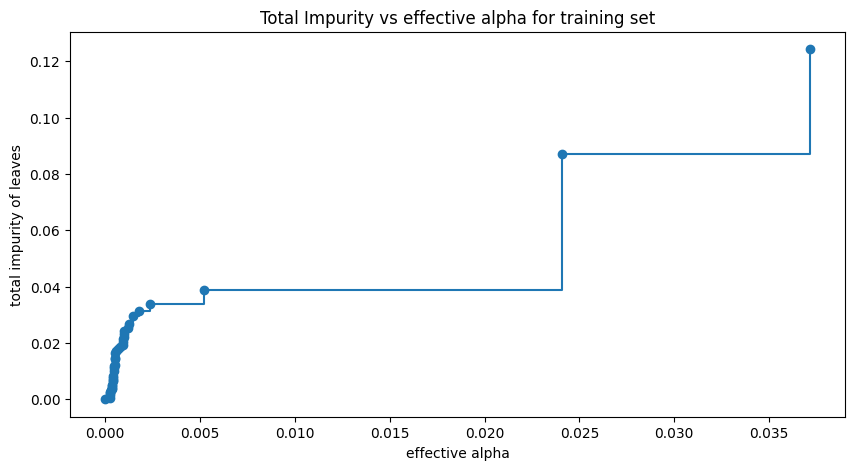

```python
fig, ax = plt.subplots(figsize=(10, 5))
ax.plot(ccp_alphas[:-1], impurities[:-1], marker="o", drawstyle="steps-post")
ax.set_xlabel("effective alpha")
ax.set_ylabel("total impurity of leaves")
ax.set_title("Total Impurity vs effective alpha for training set")
plt.show()
```

```python
clfs = []
for ccp_alpha in ccp_alphas:
    clf = DecisionTreeClassifier(random_state=1, ccp_alpha=ccp_alpha)
    clf.fit(x_train,y_train)
    clfs.append(clf)
print(
    "Number of nodes in the last tree is: {} with ccp_alpha: {}".format(
        clfs[-1].tree_.node_count, ccp_alphas[-1]
    )
)
```

```
Number of nodes in the last tree is: 1 with ccp_alpha: 0.0432588042391282
```

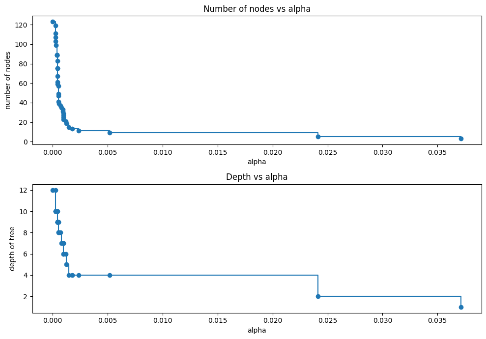

```python
clfs = clfs[:-1]
ccp_alphas = ccp_alphas[:-1]

node_counts = [clf.tree_.node_count for clf in clfs]
depth = [clf.tree_.max_depth for clf in clfs]
fig, ax = plt.subplots(2, 1, figsize=(10, 7))
ax[0].plot(ccp_alphas, node_counts, marker="o", drawstyle="steps-post")
ax[0].set_xlabel("alpha")
ax[0].set_ylabel("number of nodes")
ax[0].set_title("Number of nodes vs alpha")
ax[1].plot(ccp_alphas, depth, marker="o", drawstyle="steps-post")
ax[1].set_xlabel("alpha")
ax[1].set_ylabel("depth of tree")
ax[1].set_title("Depth vs alpha")
fig.tight_layout()
```

```python
# Recall score for training data:
recall_train = []
for clf in clfs:
    pred_train = clf.predict(x_train)
    values_of_recall_train = recall_score(y_train, pred_train)
    recall_train.append(values_of_recall_train)
#Recall score for test data:
recall_test = []
for clf in clfs:
    pred_test = clf.predict(x_test)
    values_of_recall_test = recall_score(y_test, pred_test)
    recall_test.append(values_of_recall_test)
```

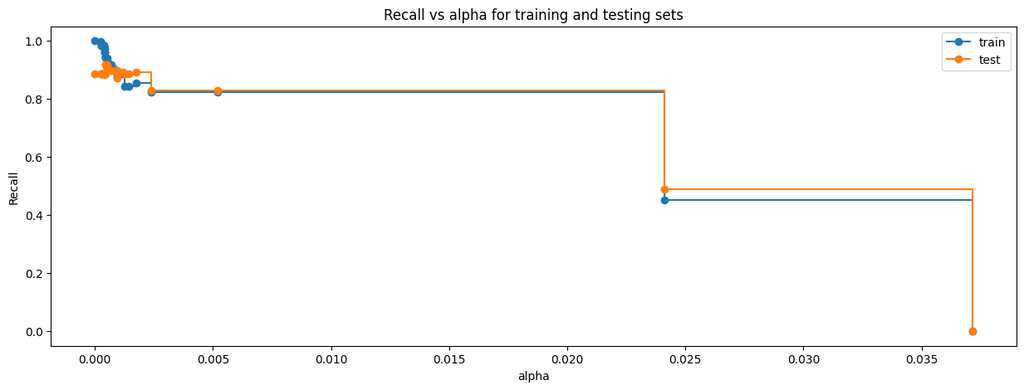

```python
fig, ax = plt.subplots(figsize=(15, 5))
ax.set_xlabel("alpha")
ax.set_ylabel("Recall")
ax.set_title("Recall vs alpha for training and testing sets")
ax.plot(ccp_alphas, recall_train, marker="o", label="train", drawstyle="steps-post")
ax.plot(ccp_alphas, recall_test, marker="o", label="test", drawstyle="steps-post")
ax.legend()
plt.show()
```

```python
# find the best model:
index_best_model = np.argmax(recall_test)
best_model = clfs[index_best_model]
print(best_model)
```

```
DecisionTreeClassifier(ccp_alpha=0.0004395604395604396, random_state=1)
```

```python
estimator2 = best_model
estimator2.fit(x_train, y_train)
```

```
DecisionTreeClassifier(ccp_alpha=0.0004395604395604396, random_state=1)
```

### Let us check the performance of the model for training:

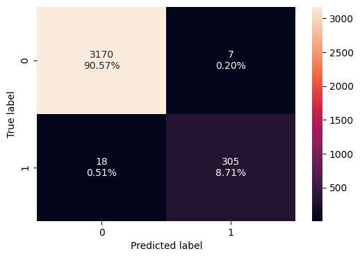

```python
confusion_matrix_sklearn(estimator2, x_train, y_train)
```

```python
decision_tree_tune_post_train = model_performance_classification_sklearn(estimator2,x_train, y_train)
decision_tree_tune_post_train
```

|  | Accuracy | Recall | Precision | F1 |
| --- | --- | --- | --- | --- |
| 0 | 0.992857 | 0.944272 | 0.977564 | 0.96063 |

- The recall is good 0.944 as well as accuracy,precision and f1.

### Let us check the performance of the model for testing:

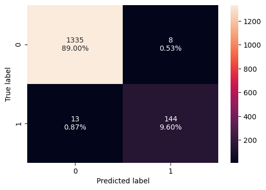

```python
confusion_matrix_sklearn(estimator2, x_test, y_test)
```

```python
decision_tree_tune_post_test= model_performance_classification_sklearn(estimator2,x_test, y_test)
decision_tree_tune_post_test
```

|  | Accuracy | Recall | Precision | F1 |
| --- | --- | --- | --- | --- |
| 0 | 0.986 | 0.917197 | 0.947368 | 0.932039 |

- The recall is good also 0.91 as well as accuracy,precision and f1.
- The recall in testing less than in training but sill doing well in both.

### Visualizing the tree:

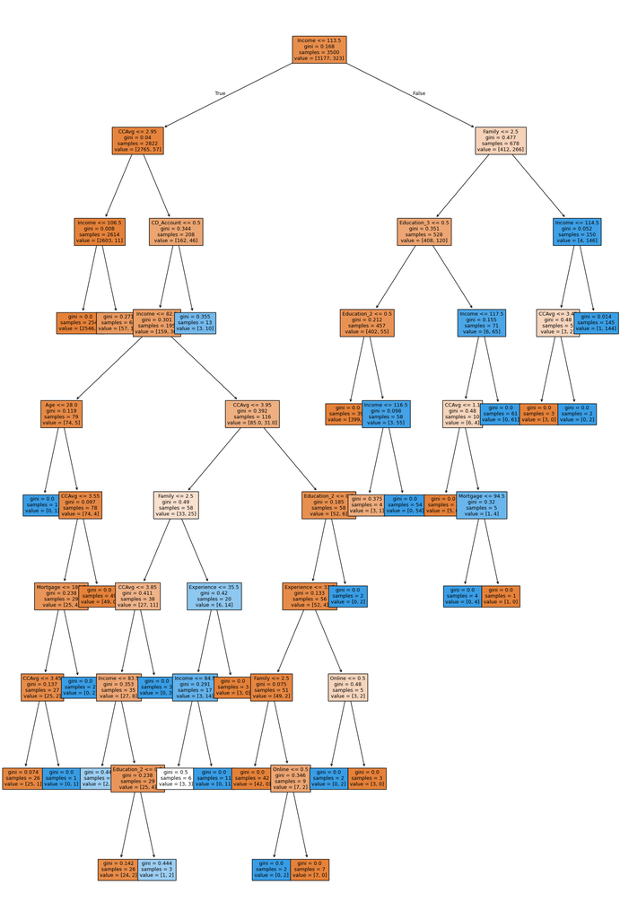

```python
plt.figure(figsize=(20, 30))
out = tree.plot_tree(
    estimator2,
    feature_names=feature_names,
    filled=True,
    fontsize=9,
    node_ids=False,
    class_names=None,
)
# below code will add arrows to the decision tree split if they are missing
for o in out:
    arrow = o.arrow_patch
    if arrow is not None:
        arrow.set_edgecolor("black")
        arrow.set_linewidth(1)
plt.show()
```

```python
# Text report showing the rules of a decision tree -

print(tree.export_text(estimator2, feature_names=feature_names, show_weights=True))
```

```
|--- Income <= 113.50
|   |--- CCAvg <= 2.95
|   |   |--- Income <= 106.50
|   |   |   |--- weights: [2546.00, 0.00] class: 0
|   |   |--- Income >  106.50
|   |   |   |--- weights: [57.00, 11.00] class: 0
|   |--- CCAvg >  2.95
|   |   |--- CD_Account <= 0.50
|   |   |   |--- Income <= 82.50
|   |   |   |   |--- Age <= 28.00
|   |   |   |   |   |--- weights: [0.00, 1.00] class: 1
|   |   |   |   |--- Age >  28.00
|   |   |   |   |   |--- CCAvg <= 3.55
|   |   |   |   |   |   |--- Mortgage <= 180.50
|   |   |   |   |   |   |   |--- CCAvg <= 3.45
|   |   |   |   |   |   |   |   |--- weights: [25.00, 1.00] class: 0
|   |   |   |   |   |   |   |--- CCAvg >  3.45
|   |   |   |   |   |   |   |   |--- weights: [0.00, 1.00] class: 1
|   |   |   |   |   |   |--- Mortgage >  180.50
|   |   |   |   |   |   |   |--- weights: [0.00, 2.00] class: 1
|   |   |   |   |   |--- CCAvg >  3.55
|   |   |   |   |   |   |--- weights: [49.00, 0.00] class: 0
|   |   |   |--- Income >  82.50
|   |   |   |   |--- CCAvg <= 3.95
|   |   |   |   |   |--- Family <= 2.50
|   |   |   |   |   |   |--- CCAvg <= 3.85
|   |   |   |   |   |   |   |--- Income <= 83.50
|   |   |   |   |   |   |   |   |--- weights: [2.00, 4.00] class: 1
|   |   |   |   |   |   |   |--- Income >  83.50
|   |   |   |   |   |   |   |   |--- Education_2 <= 0.50
|   |   |   |   |   |   |   |   |   |--- weights: [24.00, 2.00] class: 0
|   |   |   |   |   |   |   |   |--- Education_2 >  0.50
|   |   |   |   |   |   |   |   |   |--- weights: [1.00, 2.00] class: 1
|   |   |   |   |   |   |--- CCAvg >  3.85
|   |   |   |   |   |   |   |--- weights: [0.00, 3.00] class: 1
|   |   |   |   |   |--- Family >  2.50
|   |   |   |   |   |   |--- Experience <= 35.50
|   |   |   |   |   |   |   |--- Income <= 84.50
|   |   |   |   |   |   |   |   |--- weights: [3.00, 3.00] class: 0
|   |   |   |   |   |   |   |--- Income >  84.50
```

[output cut: 36 more lines]

```
|   |   |   |   |--- CCAvg >  1.10
|   |   |   |   |   |--- Mortgage <= 94.50
|   |   |   |   |   |   |--- weights: [0.00, 4.00] class: 1
|   |   |   |   |   |--- Mortgage >  94.50
|   |   |   |   |   |   |--- weights: [1.00, 0.00] class: 0
|   |   |   |--- Income >  117.50
|   |   |   |   |--- weights: [0.00, 61.00] class: 1
|   |--- Family >  2.50
|   |   |--- Income <= 114.50
|   |   |   |--- CCAvg <= 3.45
|   |   |   |   |--- weights: [3.00, 0.00] class: 0
|   |   |   |--- CCAvg >  3.45
|   |   |   |   |--- weights: [0.00, 2.00] class: 1
|   |   |--- Income >  114.50
|   |   |   |--- weights: [1.00, 144.00] class: 1
```

```python
# importance of features in the tree building ( The importance of a feature is computed as the
# (normalized) total reduction of the criterion brought by that feature. It is also known as the Gini importance )

print(
    pd.DataFrame(
        estimator2.feature_importances_, columns=["Imp"], index=x_train.columns
    ).sort_values(by="Imp", ascending=False)
)
```

```
                         Imp
Income              0.323959
Family              0.247042
Education_2         0.175929
Education_3         0.142002
CCAvg               0.065280
CD_Account          0.015224
Online              0.010071
Mortgage            0.008758
Experience          0.008487
Age                 0.003248
Securities_Account  0.000000
CreditCard          0.000000
```

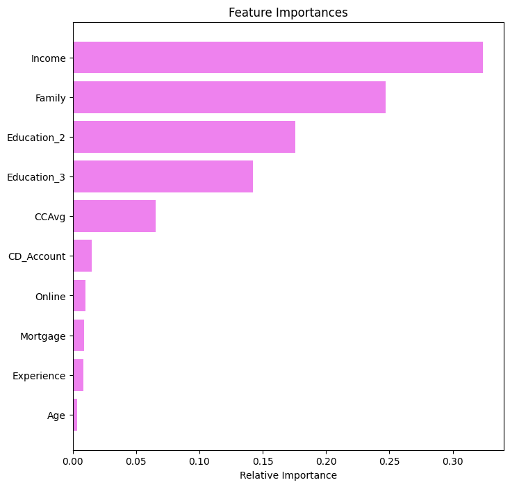

```python
importances = estimator2.feature_importances_
indices = np.argsort(importances)
N=10
top_indices = indices[-N:]
plt.figure(figsize=(8, 8))
plt.title("Feature Importances")
plt.barh(range(N), importances[top_indices], color="violet", align="center")
plt.yticks(range(N), [feature_names[i] for i in top_indices])
plt.xlabel("Relative Importance")
plt.show()
```

## Model Performance Comparison and Final Model Selection

##### Let us compare the training performances between the three models:

```python
models_train_comp_df = pd.concat(
    [decision_tree_perf_train.T, decision_tree_pre_prunning_perf_train.T, decision_tree_tune_post_train.T], axis=1,
)
models_train_comp_df.columns = ["Decision Tree (sklearn default)", "Decision Tree (Pre-Pruning)", "Decision Tree (Post-Pruning)"]
print("Training performance comparison:")
models_train_comp_df
```

```
Training performance comparison:
```

|  | Decision Tree (sklearn default) | Decision Tree (Pre-Pruning) | Decision Tree (Post-Pruning) |
| --- | --- | --- | --- |
| Accuracy | 1.0 | 0.797143 | 0.992857 |
| Recall | 1.0 | 1.000000 | 0.944272 |
| Precision | 1.0 | 0.312682 | 0.977564 |
| F1 | 1.0 | 0.476401 | 0.960630 |

OBSERVATION:

- In default tree the system doing very well in the training dataset as we notice all scores equal 1.
- For preprunning tree the recall score is perfect 1 but the other values so low .
- For post-prunning tree the recall is good as 0.944, the overall scores are good too.

##### Let us compare the testing performances between the three models:

```python
models_test_comp_df = pd.concat(
    [decision_tree_perf_test.T, decision_tree_pre_prunning_perf_test.T, decision_tree_tune_post_test.T], axis=1,
)
models_test_comp_df.columns = ["Decision Tree (sklearn default)", "Decision Tree (Pre-Pruning)", "Decision Tree (Post-Pruning)"]
print("Test set performance comparison:")
models_test_comp_df
```

```
Test set performance comparison:
```

|  | Decision Tree (sklearn default) | Decision Tree (Pre-Pruning) | Decision Tree (Post-Pruning) |
| --- | --- | --- | --- |
| Accuracy | 0.980667 | 0.796000 | 0.986000 |
| Recall | 0.885350 | 1.000000 | 0.917197 |
| Precision | 0.926667 | 0.339093 | 0.947368 |
| F1 | 0.905537 | 0.506452 | 0.932039 |

OBSERVATIONS:

- For default tree the recall is testing less than in training so the model doing well in the training but not generlaize as well as in the training.
- For the pre prunning the model doing in the test as well as in the training; high recall value and low in other scores.
- For post pruning the model generalized well.

## Actionable Insights and Business Recommendations

- What recommedations would you suggest to the bank?

RECOMMENDATIONS:

- We suggest to choose the post prunning model as it achieved good balanced comparable to the default model which indecated overfitting, and the pre prunning model which doing well in the recall but bad in precision and accuracy; which indicated that the model might predict alot of false positive values.
- We recommend to focus on the recall while keep caring the other scores to make sure the model will work well in all.
- We noticed the most important features are the Income and the family size.

```python
!jupyter nbconvert --to html /content/sample_data/AIML_ML_Project_full_code_notebook_3.ipynb
```

```
[NbConvertApp] Converting notebook /content/sample_data/AIML_ML_Project_full_code_notebook_3.ipynb to html
[NbConvertApp] WARNING | Alternative text is missing on 41 image(s).
[NbConvertApp] Writing 3385069 bytes to /content/sample_data/AIML_ML_Project_full_code_notebook_3.html
```